# Projekt 1

Dorota Łępicka, Paulina Popiołek, Agnieszka Pszczółkowska

10 listopada 2016

### Cel projektu

Celem naszego projektu było dokonanie analizy nieobecności posłów w poszczególnych partiach podczas głosowań w sejmie w trakcie 8 kadencji (dane z okresu 12. 11. 2015 r. - 04. 10. 2016 r.). W tym czasie odbyło się 1912 głosowań. Każda kropka na wykresie odpowiada jednemu politykowi.

### Analizowane dane

Do analizy użyłyśmy danych dotyczących głosowań poszczególnych posłów w okresie od 12. 11. 2015 r. do 04. 10. 2016 r.. Rozważałyśmy posłów, którzy posiadali mandat poselski w dniu 04. 10. 2016 r., pozostałych odrzuciłyśmy z analizy. Pojawiły się także przypadki posłów (11 osób), którzy w rozważanym okresie zmieniali partię. W tym wypadku przypisałyśmy im klub według stanu z dnia 04. 10. 2016 r., a liczbę nieobecności podczas głosowań zsumowałyśmy. Dodatkowo przedstawiłyśmy ich nieobecności na wykresie 3, w zależności od aktualnej przynależności do poszczególnych partii. Ponadto wyodrębniłyśmy grupę posłów ze 100% frekwencją podczas głosowań.

### Wykres 1

Warto zwrócić uwagę na nierównomierny rozkład liczby posłów w poszczególnych partiach. Niektóre z partii mają tylko kilku członków, co ma swoje konsekwencje w wyznaczonych statystykach nieobecności, umieszczonych na kolejnym wykresie. Liczbę mandatów w poszczególnych partiach przedstawia poniższy wykres. Kolory odpowiadają barwom poszczególnych klubów poselskich.

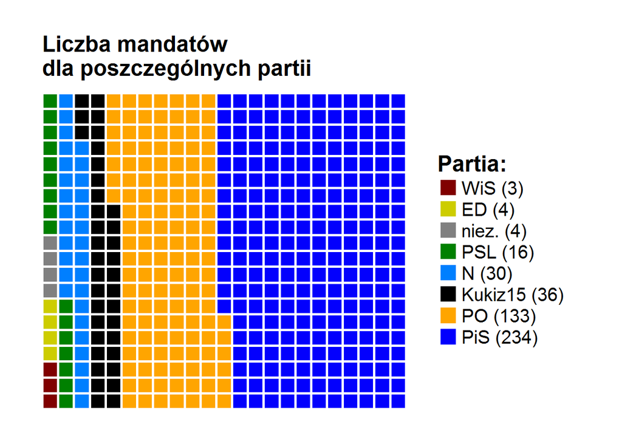

### Wykres 2

Kolejny wykres przedstawia procent nieobecności posłów na głosowaniach w zależności od partii, do których należeli w dniu 04. 10. 2016 r.. Ze względu na utracenie przez kilku posłów ich mandatów (śmierć, pełnienie innych funkcji), nie wszyscy posłowie mogli stawić się na wszystkich 1912 głosowaniach. Z tego względu frakcję nieobecności poszczególnych osób obliczamy na podstawie liczby głosowań, w których realnie mogły one uczestniczyć. Dla każdego ugrupowania pionową czerwoną linią zaznaczyłyśmy średni procent nieobecności posłów z tej partii, ponadto oznaczyłyśmy po jednej osobie z największym procentem nieobecności.

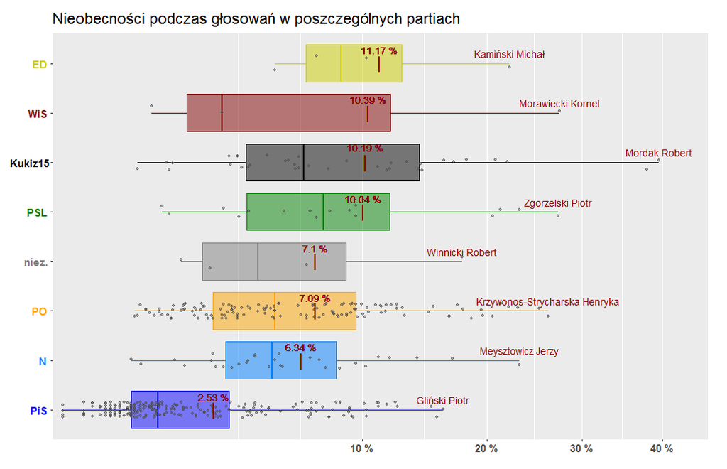

### Wykres 3

Ostatni wykres przedstawia posłów zmieniających partię w rozważanym okresie. Po najechaniu kursorem na poszczególne słupki otrzymujemy informację o tym, na ilu głosowaniach powinien być obecny, na ilu był nieobecny oraz procent nieobecności na głosowaniach w tej partii.

[interactive chart not shown]

### Wnioski

Na podstawie powyższych wykresów możemy wytypować po jednej osobie z każdej partii, która była najczęściej nieobecna na głosowaniach. Są to odpowiednio:

```
##                      surname_name    club count  ile procent
## 254                 Mordak Robert Kukiz15   755 1912   39.49
## 253             Morawiecki Kornel     WiS   525 1912   27.46
## 450              Zgorzelski Piotr     PSL   522 1912   27.30
## 193 Krzywonos-Strycharska Henryka      PO   502 1912   26.26
## 242             Meysztowicz Jerzy       N   443 1912   23.17
## 149               Kamiński Michał      ED   425 1912   22.23
## 428               Winnicki Robert   niez.   340 1912   17.78
## 103                 Gliński Piotr     PiS   308 1912   16.11
```

Ponadto można też zauważyć, że jedynie w partii PiS są posłowie, którzy byli obecni na wszystkich głosowaniach:

```
##        surname_name club count
## 1 Gonciarz Jarosław  PiS     0
## 2    Kubiak Dariusz  PiS     0
## 3 Latosiński Bogdan  PiS     0
## 4       Polak Piotr  PiS     0
## 5     Warwas Robert  PiS     0
```

```
##                      surname_name    club count  ile procent
## 254                 Mordak Robert Kukiz15   755 1912   39.49
## 425                    Wilk Jacek Kukiz15   725 1912   37.92
## 253             Morawiecki Kornel     WiS   525 1912   27.46
## 450              Zgorzelski Piotr     PSL   522 1912   27.30
## 193 Krzywonos-Strycharska Henryka      PO   502 1912   26.26
## 228          Małecka-Libera Beata      PO   483 1912   25.26
## 290             Pasławska Urszula     PSL   444 1912   23.22
## 242             Meysztowicz Jerzy       N   443 1912   23.17
## 171           Korzeniowski Leszek      PO   441 1912   23.06
## 149               Kamiński Michał      ED   425 1912   22.23
## 303             Piotrowska Teresa      PO   423 1912   22.12
```

Średnio najczęściej nieobecni byli posłowie z klubu ED oraz WiS, ale należy zwrócić, że wysokość tych średnich jest uwarunkowana małą licznością tych partii.

Można więc stwierdzić, że najczęściej na głosowaniach nie pojawiają się posłowie ugrupowania Kukiz’15, a najmniej nieobecności mają posłowie z PiS.

### Tabele

Powyższe wykresy zostały sporządzone na podstawie poniższych danych.

- Wykres 1 - liczba mandatów

```
##      club count
## 1     WiS     3
## 2      ED     4
## 3   niez.     4
## 4     PSL    16
## 5       N    30
## 6 Kukiz15    36
## 7      PO   133
## 8     PiS   234
```

- Wykres 2 - procent nieobecności na głosowaniach

```
##        club                  surname_name count  ile procent srednia
## 1        ED           Niesiołowski Stefan   196 1912   10.25   11.17
## 2        ED           Huskowski Stanisław    96 1912    5.02   11.17
## 3        ED            Protasiewicz Jacek   137 1912    7.17   11.17
## 4        ED               Kamiński Michał   425 1912   22.23   11.17
## 5   Kukiz15                 Szramka Paweł    65 1912    3.40   10.19
## 6   Kukiz15                Jakubiak Marek   273 1912   14.28   10.19
## 7   Kukiz15            Liroy-Marzec Piotr   119 1912    6.22   10.19
## 8   Kukiz15                    Apel Piotr   325 1912   17.00   10.19
## 9   Kukiz15                Bakun Wojciech    12 1912    0.63   10.19
## 10  Kukiz15              Ścigaj Agnieszka   115 1912    6.01   10.19
## 11  Kukiz15              Kobylarz Andrzej    65 1912    3.40   10.19
## 12  Kukiz15         Siarkowska Anna Maria   108 1912    5.65   10.19
## 13  Kukiz15             Sachajko Jarosław    68 1912    3.56   10.19
## 14  Kukiz15            Chruszcz Sylwester   347 1912   18.15   10.19
```

[output cut: 446 more lines]

- Wykres 3 - procent nieobecności na głosowaniach - posłowie zmieniający partie

```
##           surname_name    club count  ile procent NA
## 1  Huskowski Stanisław      ED     3   21   14.29  3
## 2  Huskowski Stanisław   niez.    11  138    7.97  2
## 3  Huskowski Stanisław      PO    82 1753    4.68  1
## 4         Jaros Michał       N    11  449    2.45  2
## 5         Jaros Michał      PO    55 1463    3.76  1
## 6      Kamiński Michał      ED     2   21    9.52  3
## 7      Kamiński Michał   niez.   122  138   88.41  2
## 8      Kamiński Michał      PO   301 1753   17.17  1
## 9         Klawiter Jan   niez.    29 1901    1.53  2
## 10        Klawiter Jan     PiS     1   11    9.09  1
## 11    Kobyliński Paweł Kukiz15    17  176    9.66  1
## 12    Kobyliński Paweł       N   150 1668    8.99  3
## 13    Kobyliński Paweł   niez.    61   68   89.71  2
## 14   Morawiecki Kornel Kukiz15   323 1088   29.69  1
## 15   Morawiecki Kornel     WiS   202  694   29.11  2
## 16 Niesiołowski Stefan      ED     1   21    4.76  2
## 17 Niesiołowski Stefan      PO   195 1891   10.31  1
## 18  Protasiewicz Jacek   niez.     8  138    5.80  2
## 19  Protasiewicz Jacek      PO   129 1753    7.36  1
## 20     Winnicki Robert Kukiz15   273 1090   25.05  1
## 21     Winnicki Robert   niez.    67  822    8.15  2
## 22 Zwiercan Małgorzata Kukiz15    15 1088    1.38  1
## 23 Zwiercan Małgorzata     WiS     2  694    0.29  2
## 24      Zyska Ireneusz Kukiz15    45 1218    3.69  1
## 25      Zyska Ireneusz     WiS     9  694    1.30  2
```

### Kod

```
library(sejmRP)
library(dplyr)
library(ggplot2)
library(ggrepel)
library(waffle)
library(plotly)
library(ggthemes)

# Wczytujemy interesujace nas dane z 8 kadencji.
dane<-get_filtered_votes( dates = c("2015-11-12", "2016-10-04"))

# Wyznaczamy aktualną liste poslow
ostatnie_posiedzenie<-dane %>%
  filter(date_meeting=="2016-10-04", nr_voting==2)
aktualna_lista<-ostatnie_posiedzenie$surname_name
dane1<-dane[which(dane$surname_name %in% aktualna_lista),]

# Zliczamy nieobecnosci kazdego posla
nieobecni <- dane1%>%
  filter(vote=="Nieobecny") %>%
  group_by(surname_name, club) %>%
  summarise(count=n())

# Poslowie obecni na wszystkich glosowaniach
brak_nieobecnosci<-dane1 %>%
  filter(vote!="Nieobecny")%>%
  group_by(surname_name, club) %>%
  summarise(count=n())
brak_nieobecnosci<-brak_nieobecnosci[which(brak_nieobecnosci$count==1912),]
brak_nieobecnosci$count<-0

# Poslowie bedacych w kilku partiach w 8 kadencji
w_kilku_partiach<-sort(table(nieobecni$surname_name), decreasing = T)[1:11]
w_kilku_partiach<-labels(w_kilku_partiach)[[1]]

# Poslowie nieobecni na glosowaniach, bedacy w kilku partiach
nieobecny_kilka_partii<-dane1%>%
  filter(vote=="Nieobecny",surname_name %in% w_kilku_partiach ) %>%
  group_by(surname_name) %>%
  summarise(count=n())
```

[output cut: 99 more lines]

```
        axis.text.y = element_text(size=18, face="bold"),
        plot.title=element_text(margin=margin(b=0.5, unit="cm"), hjust=0, size=18, face="bold"),
        panel.grid.major.y=element_blank())+
  scale_y_sqrt(expand = c(0, 0),breaks=c(0,10,20,30,40,50,60,70,80,90),labels=c(paste(0,"%"),
               paste(10,"%"), paste(20,"%"), paste(30,"%"),paste(40,"%"),paste(50,"%"),paste(60,"%"),
               paste(70,"%"),paste(80,"%"),paste(90,"%")), limits=c(0,95))+
  scale_fill_manual(values=kolory)+
  xlab(" ")+
  ylab(" ")+
  ggtitle("Nieobecności podczas głosowań dla posłów, który zmieniali partie")+
  coord_flip()+
  theme_grey()+
  guides(fill=FALSE, color=FALSE)

p %>% ggplotly(originalData = FALSE,tooltip=c("Partia", "text"), legend=FALSE)
```